# Farming Project

# Import necessary packages

```r
library(readxl)
library(tidyverse)
```

# Key Note:

**This notebook aims to cover the following:**

1. Load the Different Folders containing the different food categories (Maize,Beans,Wheat) we would like to analyse.
2. Merge the various datasets contained in the folders to have three main datasets
3. Perform Data cleaning on the Data to prepare it for time series Analysis. > Challenge: How to Adress the missing prices either retail or wholesale prices
4. Visualize the different datasets to see what time series components are available in the data.
5. Try grouping and summarizing different prices based on daily,monthly prices to observe the trends and seasonality in the food crops data.

## Maize

```r
dim(Maize_df)
```

```
[1] 31847    10
```

### Inspecting the data

- We anticipate the data to have duplicates during data importing from Kamis website
- Also we need to sort the data with respect to the dates in order of recent dates

```r
sum(duplicated(Maize_df))
```

```
[1] 1421
```

[output not shown]

[output cut: 990 more lines]

### Data Cleaning

```r
# Retaining the essential columns
Maize_df %>% select(Wholesale,Retail,Date) ->Final_data
tail(Final_data)
```

| Wholesale | Retail | Date |
| --- | --- | --- |
| 40.00/Kg | 54.55/Kg | 2025-03-14 |
| - | 55.00/Kg | 2025-03-14 |
| - | 35.56/Kg | 2025-03-14 |
| 50.00/Kg | 60.00/Kg | 2025-03-14 |
| 5.71/Kg | 50.00/Kg | 2025-03-14 |
| 45.00/Kg | 55.00/Kg | 2025-03-14 |

```r
dim(Final_data)
```

```
[1] 30426     3
```

```r
summary(Final_data)
```

```
   Wholesale           Retail             Date
 Min.   :   0.01   Min.   :   0.01   Min.   :2005-02-01
 1st Qu.:  30.00   1st Qu.:  45.00   1st Qu.:2021-05-24
 Median :  40.00   Median :  60.00   Median :2022-05-19
 Mean   :  54.43   Mean   :  79.43   Mean   :2020-01-02
 3rd Qu.:  61.11   3rd Qu.:  80.00   3rd Qu.:2023-05-06
 Max.   :7000.00   Max.   :9000.00   Max.   :2025-03-14
 NA's   :3809      NA's   :9562
```

Something worth investigating is why some of the prices are as low as 0.01 and high as 7k and 9k could probably be created during data collection. Let’s investigate prices less than the first quartile to see whether we should retain them later for modelling.

First we will remove price for the wholesale and retail that are below 10 and above 200. Based on the research from various verified government sources the prices can not logically exceed below and above the given range. **Note:** > - If applied the filter function for the above logic in both columns we experience alot of data loss this contributed by the high number of missing values. - A better way is to filter out the two price columns separate this helps retaining as much data as possible.Check summary statistics below

```r
Final_data %>% filter(Wholesale >10 & Wholesale <200 ) %>% select(-Retail) %>% summary()
```

```
   Wholesale           Date
 Min.   : 11.11   Min.   :2005-02-01
 1st Qu.: 30.00   1st Qu.:2013-08-27
 Median : 40.00   Median :2022-05-27
 Mean   : 46.30   Mean   :2019-08-09
 3rd Qu.: 61.11   3rd Qu.:2023-04-24
 Max.   :194.55   Max.   :2025-03-14
```

```r
print('Data Dimension on filtering')
```

```
[1] "Data Dimension on filtering"
```

```r
Final_data %>% filter(Wholesale >10 & Wholesale <200 ) %>% select(-Retail) %>% dim()
```

```
[1] 26300     2
```

```r
Final_data %>% filter(Retail >10 & Retail < 200) %>% select(-Wholesale) %>% summary() #%>% head()
```

```
     Retail            Date
 Min.   : 11.25   Min.   :2021-05-26
 1st Qu.: 45.00   1st Qu.:2022-03-11
 Median : 60.00   Median :2022-11-12
 Mean   : 63.22   Mean   :2023-01-02
 3rd Qu.: 76.92   3rd Qu.:2023-08-17
 Max.   :195.00   Max.   :2025-03-14
```

```r
print('Data Dimension on filtering')
```

```
[1] "Data Dimension on filtering"
```

```r
Final_data %>% filter(Retail >10 & Retail < 200) %>% select(-Wholesale) %>% dim() #%>% head()
```

```
[1] 20448     2
```

```r
# Filtering the two have two separate datasets
Final_data %>% filter(Wholesale >10 & Wholesale < 200 ) %>% select(-Retail)-> Wholesale_data

Final_data %>% filter( Retail >10 & Retail < 200 ) %>% select(-Wholesale)-> Retail_data
```

> Call it killing two birds with one stone 😂😂😂 We dropped the missing values in the data when applying the filter function. But introduced time series data irreguralities meaning we have some gaps in the data through time.

### WholeSale Prices

- Since we have prices from different markets we are going to use the mean average of the prices in a day as the prices we would want to investigate.
- Something that caught my attention is the missing data from 2014 Jan to 2021 May. * I was thinking imputing the data for this time missing time sounds impractical so I sought to remove data below 2021 until I figure out way to retrieve the missing data

```r
Wholesale_data %>% filter(Date > as.Date("2021-01-01")) %>% group_by(Date) %>% summarise(Wholesale_mean = round(mean(Wholesale),2)) ->Mean_wholesale

Mean_wholesale %>% head()
```

| Date | Wholesale_mean |
| --- | --- |
| 2021-05-26 | 31.36 |
| 2021-05-27 | 35.60 |
| 2021-05-28 | 28.82 |
| 2021-05-29 | 34.54 |
| 2021-05-30 | 26.67 |
| 2021-05-31 | 31.80 |

As mentioned above we need to fist address irregularities in the time series data and we will use the zoo package for that

```r
# Creating a zoo object
Wholesale_zoo <-zoo(Mean_wholesale$Wholesale_mean,Mean_wholesale$Date)

# Identifying the missing data
full_dates <- seq(min(Mean_wholesale$Date),max(Mean_wholesale$Date),by= 'day')
length(full_dates)
```

```
[1] 1389
```

```r
# Merge with all dates, introducing NAs for missing dates
z_full <- merge.zoo(Wholesale_zoo, zoo(, full_dates), all = TRUE)
print(z_full)
```

[output not shown]

[output cut: 232 more lines]

[output not shown]

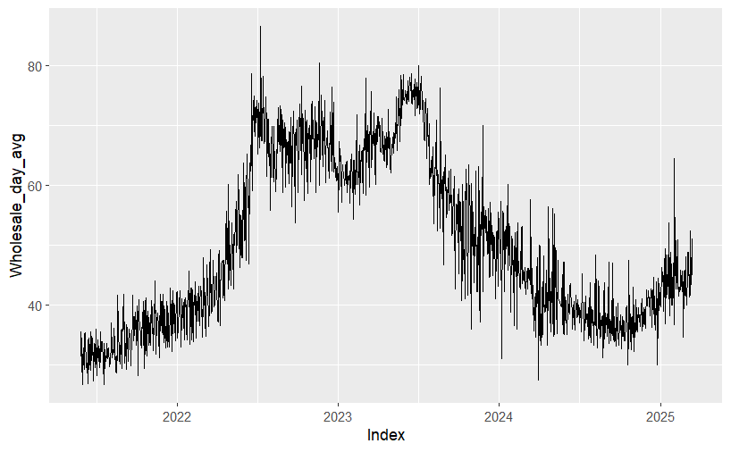

```r
# Using Linear Interpolation to fill in missing values
Wholesale_day_avg <- na.approx(z_full)

# Plot the interpolated data
autoplot(Wholesale_day_avg)
```

```r
# Check if the data is irregular
is.regular(Wholesale_day_avg)
```

```
[1] TRUE
```

From the plot it is evident linear interpolation does really work well with our data but we could smooth the data . A different approach to this we could aggregate the data further into monthly prices for the wholesale data to see if the data can be smoother.

```r
Wholesale_month_avg <-aggregate(Wholesale_zoo,as.yearmon,mean)
Wholesale_month_avg
```

```
May 2021 Jun 2021 Jul 2021 Aug 2021 Sep 2021 Oct 2021 Nov 2021 Dec 2021
31.46500 31.84600 31.69452 33.24839 34.99133 35.96903 37.46367 37.42032
Jan 2022 Feb 2022 Mar 2022 Apr 2022 May 2022 Jun 2022 Jul 2022 Aug 2022
38.59516 39.64107 42.16645 45.91467 51.93935 63.85967 69.50968 66.47871
Sep 2022 Oct 2022 Nov 2022 Dec 2022 Jan 2023 Feb 2023 Mar 2023 Apr 2023
66.03533 67.52097 68.67733 65.91767 61.87806 62.86786 67.26419 67.16967
May 2023 Jun 2023 Jul 2023 Aug 2023 Sep 2023 Oct 2023 Nov 2023 Dec 2023
70.83355 75.35300 70.62161 60.98258 56.59200 52.32097 51.60533 50.50483
Jan 2024 Feb 2024 Mar 2024 Apr 2024 May 2024 Jun 2024 Jul 2024 Aug 2024
49.62833 46.36893 42.71500 41.00897 41.88115 39.19133 38.24677 37.71516
Sep 2024 Oct 2024 Nov 2024 Dec 2024 Jan 2025 Feb 2025 Mar 2025
36.90733 36.60871 37.63714 40.27161 44.35333 44.53786 45.29846
```

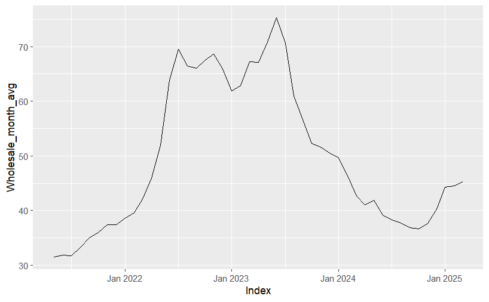

```r
autoplot(Wholesale_month_avg)
```

### Check for Time series components

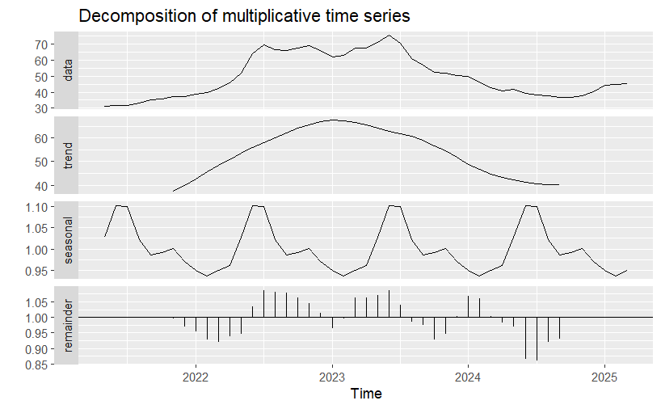

```r
Wholesale_ts <-as.ts(Wholesale_month_avg)
autoplot(decompose(Wholesale_ts,type = 'multiplicative'))
```

[figure not shown]

[figure not shown]

```r
Wholesale_ts
```

```
          Jan      Feb      Mar      Apr      May      Jun      Jul      Aug
2021                                     31.46500 31.84600 31.69452 33.24839
2022 38.59516 39.64107 42.16645 45.91467 51.93935 63.85967 69.50968 66.47871
2023 61.87806 62.86786 67.26419 67.16967 70.83355 75.35300 70.62161 60.98258
2024 49.62833 46.36893 42.71500 41.00897 41.88115 39.19133 38.24677 37.71516
2025 44.35333 44.53786 45.29846
          Sep      Oct      Nov      Dec
2021 34.99133 35.96903 37.46367 37.42032
2022 66.03533 67.52097 68.67733 65.91767
2023 56.59200 52.32097 51.60533 50.50483
2024 36.90733 36.60871 37.63714 40.27161
2025
```